# Hurricane Helene Satellite Image Dataset

Southwest Virginia · Sentinel-1 & Sentinel-2 · Treatment & Counterfactual Sites

Published

August 18, 2026

This repository contains two complementary versions of the Hurricane Helene satellite image dataset. Both versions cover the same treatment and counterfactual site boundaries in southwest Virginia.

| Version | Design | Best for |
| --- | --- | --- |
| **Version 1 — Median Before/After** | One median composite image per site for the pre-hurricane period and one for the post-hurricane period | Quick visual comparison, initial change detection |
| **Version 2 — Time-Series** | Acquisition-level, weekly (7-day), and biweekly (14-day) composites spanning a 280-day study window | Longitudinal analysis, counterfactual modeling, representation learning |

Version 1 preserves the original two-image dataset. Version 2 extends the temporal dimension and does not replace Version 1.

**Version 1 — Median Before/After**

### Overview

Version 1 supports a straightforward before-and-after comparison of locations affected by Hurricane Helene and matched counterfactual locations without mapped Helene-triggered landslides nearby.

The final product contains:

- treatment and counterfactual site boundaries (GeoJSON);
- Sentinel-2 optical imagery (8 bands);
- Sentinel-1 SAR imagery (3 bands);
- one before and one after image chip per site;
- treatment-to-counterfactual matching files;
- image inventories and validation tables.

### Study design

#### Treatment sites

Treatment sites are centered on landslide locations in the USGS preliminary Hurricane Helene landslide inventory for Virginia. Each site is represented by an approximately 1 km × 1 km image chip.

#### Counterfactual sites

Each treatment site is matched to **10 counterfactual sites** selected using the following rules:

- at least 5 km from every treatment location;
- same NLCD land-cover class as the matched treatment site;
- similar elevation and terrain slope;
- drawn from the southwest Virginia study area;
- not reused across treatment sites.

> **Limitation:** a counterfactual site should not be interpreted as completely unaffected by Hurricane Helene. It may still have experienced rainfall, flooding, or unrecorded damage. The 5 km exclusion rule only separates controls from *mapped* treatment locations.

#### Event periods

| Period | Start | End |
| --- | --- | --- |
| Before | 2024-08-15 | 2024-09-23 |
| After | 2024-10-01 | 2024-10-31 |

For each site and period, the workflow composites all eligible satellite scenes that intersect the site into a single median image.

### Folder structure

```
finals/
├── treatment_sites.geojson
├── counterfactual_sites.geojson
├── all_sites.geojson
├── site_matching_table.csv
│
├── sentinel2/
│   ├── treatment/
│   │   ├── before/        ← treatment_NNNN_before_sentinel2.tif
│   │   └── after/         ← treatment_NNNN_after_sentinel2.tif
│   ├── counterfactual/
│   │   ├── before/        ← counterfactual_NNNN_RR_before_sentinel2.tif
│   │   └── after/         ← counterfactual_NNNN_RR_after_sentinel2.tif
│   ├── previews/
│   ├── sentinel2_image_inventory.csv
│   ├── sentinel2_image_validation.csv
│   ├── sentinel2_site_completeness.csv
│   ├── sentinel2_matched_pair_completeness.csv
│   ├── sentinel2_analysis_ready_inventory.csv
│   └── sentinel2_folder_summary.csv
│
└── sentinel1/
    ├── treatment/
    │   ├── before/        ← treatment_NNNN_before_sentinel1.tif
    │   └── after/         ← treatment_NNNN_after_sentinel1.tif
    ├── counterfactual/
    │   ├── before/        ← counterfactual_NNNN_RR_before_sentinel1.tif
    │   └── after/         ← counterfactual_NNNN_RR_after_sentinel1.tif
    ├── sentinel1_image_inventory.csv
    ├── sentinel1_image_validation.csv
    ├── sentinel1_site_completeness.csv
    ├── sentinel1_matched_pair_completeness.csv
    ├── sentinel1_analysis_ready_inventory.csv
    └── sentinel1_folder_summary.csv
```

`NNNN` = zero-padded site number; `RR` = control rank (01–10).

### Site files

#### `treatment_sites.geojson`

One polygon per treatment image window. Key fields:

| Field | Description |
| --- | --- |
| `site_id` | Unique treatment identifier |
| `pair_id` | Treatment group identifier |
| `group` | `"treatment"` |
| `control_rank` | 0 for treatment sites |
| `elevation_m` | Elevation at site center |
| `slope_deg` | Slope at site center |
| `nlcd_class` | NLCD land-cover class |
| `geometry` | Image-window polygon |

#### `counterfactual_sites.geojson`

Ten matched counterfactual polygons per treatment site. Key fields:

| Field | Description |
| --- | --- |
| `site_id` | Unique counterfactual identifier |
| `pair_id` | Matched treatment group |
| `matched_treatment_id` | Treatment site this control is assigned to |
| `control_rank` | Rank 1–10 within the treatment group |
| `group` | `"counterfactual"` |
| `elevation_m` | Elevation at site center |
| `slope_deg` | Slope at site center |
| `nlcd_class` | NLCD land-cover class |

#### `all_sites.geojson`

Treatment and counterfactual polygons combined in one file.

#### `site_matching_table.csv`

One row per treatment-counterfactual match. Key fields:

| Field | Description |
| --- | --- |
| `pair_id` | Treatment group |
| `treatment_site_id` | Treatment site |
| `counterfactual_site_id` | Matched counterfactual |
| `control_rank` | Rank within group |
| `match_quality` | Matching score |
| `nlcd_class` | Shared land-cover class |
| `elevation_m` (treatment & control) | Elevation at each site |
| `elevation_diff_m` | Elevation difference |
| `slope_deg` (treatment & control) | Slope at each site |
| `slope_diff_deg` | Slope difference |
| `distance_m` | Treatment-to-control distance |

Use this file to connect each counterfactual image to its treatment site.

### Sentinel-2 optical imagery

#### File naming

```
treatment_0001_before_sentinel2.tif
treatment_0001_after_sentinel2.tif
counterfactual_0001_01_before_sentinel2.tif
counterfactual_0001_01_after_sentinel2.tif
```

Always use `site_matching_table.csv` or the `site_id` field in the GeoJSON files rather than relying on filename parsing alone.

#### Band table

| Band | Name | Description |
| --- | --- | --- |
| 1 | B2 | Blue reflectance |
| 2 | B3 | Green reflectance |
| 3 | B4 | Red reflectance |
| 4 | B8 | Near-infrared reflectance |
| 5 | B11 | Shortwave infrared 1 |
| 6 | B12 | Shortwave infrared 2 |
| 7 | NDVI | Normalized Difference Vegetation Index |
| 8 | NDWI | Normalized Difference Water Index |

Reflectance bands are scaled to approximately 0–1. Images are cloud- and shadow-masked using the Sentinel-2 Scene Classification Layer and composited using the pixel-wise median over the period.

#### Recommended uses

- **RGB visualization:** bands 3, 2, 1
- **Vegetation condition:** NDVI (band 7)
- **Surface water / wetness:** NDWI (band 8)
- **Soil exposure and moisture change:** B11 and B12 (bands 5–6)
- **Change detection:** after image minus before image
- **Image segmentation or classification**
- **Treatment vs. counterfactual representation learning**

#### Python example

```python
import rasterio
import numpy as np

path = "finals/sentinel2/treatment/before/treatment_0001_before_sentinel2.tif"

with rasterio.open(path) as src:
    data = src.read(masked=True)   # shape: (8, H, W)
    profile = src.profile

blue, green, red = data[0], data[1], data[2]
nir, swir1, swir2 = data[3], data[4], data[5]
ndvi, ndwi = data[6], data[7]

rgb = np.stack([red, green, blue], axis=-1)
```

### Sentinel-1 SAR imagery

#### File naming

```
treatment_0001_before_sentinel1.tif
treatment_0001_after_sentinel1.tif
counterfactual_0001_01_before_sentinel1.tif
counterfactual_0001_01_after_sentinel1.tif
```

#### Band table

| Band | Name | Description |
| --- | --- | --- |
| 1 | VV | VV-polarized radar backscatter (dB) |
| 2 | VH | VH-polarized radar backscatter (dB) |
| 3 | VV_minus_VH | VV minus VH (dB) |

**Processing parameters:** `COPERNICUS/S1_GRD`, Interferometric Wide Swath mode, 10 m resolution, dual VV/VH polarization, ascending orbit, median composite, edge pixels masked.

#### Recommended uses

- Flood and surface-water detection
- Soil-moisture and wetness change
- Vegetation-structure change
- Landslide and exposed-surface detection
- Cloud-independent before/after comparison
- Fusion with Sentinel-2 optical data

#### Python example

```python
import rasterio

path = "finals/sentinel1/treatment/before/treatment_0001_before_sentinel1.tif"

with rasterio.open(path) as src:
    data = src.read(masked=True)   # shape: (3, H, W)

vv, vh, vv_minus_vh = data[0], data[1], data[2]
```

### Pairing treatment and counterfactual images

```
treatment_0001
├── Sentinel-2 before / after
├── Sentinel-1 before / after
└── 10 matched counterfactual sites
    ├── rank 01 — before / after (Sentinel-1 & Sentinel-2)
    ├── rank 02 — before / after
    ├── ...
    └── rank 10 — before / after
```

**Recommended workflow:**

1. Read `site_matching_table.csv`.
2. Select a `treatment_site_id`.
3. Retrieve its 10 `counterfactual_site_id` values.
4. Load before and after images for the treatment site.
5. Load before and after images for all 10 controls.
6. Compute site-level or pixel-level change measures.
7. Compare treatment change against the distribution of control changes.

### Suggested change measures

For any image-derived feature *Y*:

```
Treatment change  =  Y_treatment_after  − Y_treatment_before
Control change    =  Y_control_after    − Y_control_before

Adjusted change   =  Treatment change
                   − mean(Control change across 10 matched controls)
```

Possible features include mean NDVI, NDWI, B11, B12, VV, VH, fraction of pixels exceeding a damage threshold, or learned image embeddings.

### Image alignment notes

Before pixel-level subtraction or sensor fusion, verify:

- CRS, pixel resolution, raster dimensions, affine transform
- Valid-pixel mask and nodata coverage

Sentinel-1 and Sentinel-2 chips cover the same polygon but do **not** automatically share identical pixel grids. Reproject or resample to a common grid before fusion. Use **bilinear** resampling for continuous data; use **nearest-neighbor** for categorical masks. Do **not** treat masked pixels as zero.

### Metadata and quality-control files

| File | Contents |
| --- | --- |
| `sentinel{1,2}_image_inventory.csv` | One row per requested image: site ID, group, period, source collection, scene count, status, file path, size, errors |
| `sentinel{1,2}_image_validation.csv` | Per-file existence, readability, band count, dimensions, CRS, resolution, valid-pixel fraction |
| `sentinel{1,2}_site_completeness.csv` | Sites with both before and after images |
| `sentinel{1,2}_matched_pair_completeness.csv` | Treatment groups with complete treatment and counterfactual imagery |
| `sentinel{1,2}_analysis_ready_inventory.csv` | Images that passed before/after completeness checks |

### Recommended first checks

1. Confirm the number of treatment and counterfactual sites.
2. Confirm every treatment has 10 controls in `site_matching_table.csv`.
3. Confirm each site has before and after Sentinel-1 and Sentinel-2 chips.
4. Inspect the validation CSV files (band count, dimensions, valid-pixel fraction).
5. Visualize several treatment-control pairs.
6. Decide whether the analysis will use pixel-level change, image-level features, or learned embeddings.

### Important limitations

1. Treatment locations are based on mapped landslide *points*, not complete landslide footprints.
2. The USGS inventory is preliminary and may not contain every Helene-related landslide.
3. Counterfactual sites are outside the 5 km buffer but may still have experienced other hurricane effects.
4. Median composites summarize a date range rather than a single acquisition.
5. Optical imagery may retain missing pixels after cloud masking.
6. Radar backscatter is affected by viewing geometry, terrain, vegetation structure, and moisture.
7. Matching balances selected observed characteristics but does not guarantee equivalence on unobserved characteristics.
8. Image chips are centered on point locations and may include unaffected land around the mapped feature.

**Version 2 — Time-Series**

### Overview

Version 2 converts the project from a two-period before/after dataset into a **repeated temporal panel**. It uses the same treatment and counterfactual sites but provides acquisition-level imagery plus weekly (7-day) and biweekly (14-day) composites across a 280-day window centered on Hurricane Helene.

**Current working sample:**

| Group | Sites |
| --- | --- |
| Treatment | 10 |
| Counterfactual (5 per treatment) | 50 |
| Total spatial units | 60 |

The same 60 spatial units appear across the acquisition-level, weekly, and biweekly datasets so that temporal resolutions can be compared directly.

The authoritative working-sample file is:

```
finals/daily_datasets/selected_site_sample.csv
```

> The current 5-controls-per-treatment sample is for developing and testing the pipeline. It should not be treated as the final donor pool for causal estimation.

### Why extend the study period?

Version 1 was designed for a simple before/after comparison. It summarizes a short pre-hurricane window and a short post-hurricane window into one median image on each side of Hurricane Helene. That design is useful for visualization, but it removes most of the temporal information in the satellite archive.

For data-driven counterfactual methods — especially synthetic-control-style or latent-representation approaches — one pre-event image is generally not enough. The model needs repeated observations before the hurricane to verify that treatment and candidate counterfactual sites move similarly over time.

Version 2 therefore extends the study window symmetrically:

| Period | Start | End | Length |
| --- | --- | --- | --- |
| Before | 2024-05-10 | 2024-09-26 | 140 days |
| After | 2024-09-27 | 2025-02-13 | 140 days |

September 27, 2024 is the first AFTER date. The symmetric 140-day windows provide:

- a substantially longer pre-hurricane trajectory for model fitting;
- enough observations to evaluate pre-event treatment-control similarity;
- repeated post-hurricane observations for persistence and recovery analysis;
- exactly **40 non-overlapping 7-day periods** (20 before and 20 after);
- exactly **20 non-overlapping 14-day periods** (10 before and 10 after).

The extended window also introduces seasonal variation, which should be modeled explicitly when interpreting post-hurricane changes.

### Processing workflow

The time-period pipeline is staged so that acquisition-level imagery is downloaded only once and all temporal composites are built locally.

```
Treatment / counterfactual sample
        │
        ▼
Notebook 10 — Download & validate acquisition-level Sentinel-1 & Sentinel-2
        │
        ├─────────────────────┐
        ▼                     ▼
Notebook 11              Notebook 12
7-day composites         14-day composites
(weekly_datasets/)       (biweekly_datasets/)
        │                     │
        └──────────┬──────────┘
                   ▼
           Notebook 13
           Compare image quality & temporal availability
                   │
                   ▼
           Choose working temporal resolution
```

### Sub-datasets

#### Acquisition-level (`daily_datasets/`)

Notebook 10 is the single source of truth for the time-series imagery.

For each selected site and sensor, it stores the actual satellite scenes available during the study window with the acquisition date retained in the filename. Importantly:

> This dataset is called `daily_datasets` for convenience, but it does **not** mean that every site has one satellite image every calendar day. It contains actual acquisition dates when Sentinel-1 or Sentinel-2 imagery was available.

**File naming:**

```
treatment_0001_2024-05-20_sentinel2.tif
counterfactual_0001_01_2024-05-20_sentinel2.tif
```

**Folder layout:**

```
daily_datasets/
├── sentinel1/
│   ├── treatment/
│   │   ├── before/
│   │   └── after/
│   └── counterfactual/
│       ├── before/
│       └── after/
├── sentinel2/
│   ├── treatment/
│   │   ├── before/
│   │   └── after/
│   └── counterfactual/
│       ├── before/
│       └── after/
├── selected_site_sample.csv
├── daily_satellite_inventory.csv
├── daily_dataset_summary.csv
├── daily_calendar_index.csv
├── daily_download_action_summary.csv
├── daily_folder_summary.csv
├── sentinel1_daily_inventory.csv
└── sentinel2_daily_inventory.csv
```

#### Weekly composites (`weekly_datasets/`)

Notebook 11 divides each side of the hurricane into non-overlapping **7-day windows** and applies the following compositing rule:

| Available acquisitions | Result |
| --- | --- |
| 0 | No TIFF produced; period recorded as missing |
| 1 | Weekly image = that single acquisition |
| 2+ | Pixel-wise NaN-aware median |

Each site has a fixed potential panel of 40 periods:

```
before_W01 … before_W20   (weeks 1–20 before the hurricane)
after_W01  … after_W20    (weeks 1–20 after the hurricane)
```

**File naming:**

[output not shown]

**Folder layout:**

```
weekly_datasets/
├── sentinel1/
│   ├── treatment/    { before/ after/ }
│   └── counterfactual/  { before/ after/ }
├── sentinel2/
│   ├── treatment/    { before/ after/ }
│   └── counterfactual/  { before/ after/ }
├── weekly_image_quality.csv
├── weekly_image_quality.xlsx
├── weekly_quality_summary.csv
├── weekly_sample_validation.csv
├── weekly_period_definitions.csv
├── weekly_period_dimension.csv
├── weekly_site_dimension.csv
├── weekly_build_action_summary.csv
└── weekly_folder_summary.csv
```

#### Biweekly composites (`biweekly_datasets/`)

Notebook 12 applies the same compositing logic using non-overlapping **14-day windows**:

| Available acquisitions | Result |
| --- | --- |
| 0 | No TIFF produced; period recorded as missing |
| 1 | Biweekly image = that single acquisition |
| 2+ | Pixel-wise NaN-aware median |

Each site has a fixed potential panel of 20 periods:

```
before_P01 … before_P10   (periods 1–10 before the hurricane)
after_P01  … after_P10    (periods 1–10 after the hurricane)
```

The median is computed independently for every band and spatial pixel, ignoring NaN values. For example:

```
Acquisition 1 pixel = NaN   (cloud-masked)
Acquisition 2 pixel = 0.52
Acquisition 3 pixel = 0.61

Biweekly composite = median(0.52, 0.61) = 0.565
```

This means cloud-masked pixels from one Sentinel-2 acquisition can sometimes be filled by valid observations from another acquisition in the same 14-day window.

**File naming:**

[output not shown]

**Folder layout:**

```
biweekly_datasets/
├── sentinel1/
│   ├── treatment/    { before/ after/ }
│   └── counterfactual/  { before/ after/ }
├── sentinel2/
│   ├── treatment/    { before/ after/ }
│   └── counterfactual/  { before/ after/ }
├── biweekly_image_quality.csv
├── biweekly_image_quality.xlsx
├── biweekly_quality_summary.csv
├── biweekly_sample_validation.csv
├── biweekly_period_definitions.csv
├── biweekly_period_dimension.csv
├── biweekly_site_dimension.csv
├── biweekly_build_action_summary.csv
└── biweekly_folder_summary.csv
```

### Full Version 2 folder structure

```
finals/
├── treatment_sites.geojson
├── counterfactual_sites.geojson
├── all_sites.geojson
├── site_matching_table.csv
│
├── daily_datasets/          ← acquisition-level imagery (actual pass dates)
│   ├── sentinel1/
│   │   ├── treatment/    { before/ after/ }
│   │   └── counterfactual/  { before/ after/ }
│   ├── sentinel2/
│   │   ├── treatment/    { before/ after/ }
│   │   └── counterfactual/  { before/ after/ }
│   ├── selected_site_sample.csv
│   └── daily_satellite_inventory.csv
│
├── weekly_datasets/         ← 7-day composites  (W01–W20 × before/after)
│   ├── sentinel1/
│   │   ├── treatment/    { before/ after/ }
│   │   └── counterfactual/  { before/ after/ }
│   ├── sentinel2/
│   │   ├── treatment/    { before/ after/ }
│   │   └── counterfactual/  { before/ after/ }
│   └── [quality & metadata CSVs]
│
├── biweekly_datasets/       ← 14-day composites (P01–P10 × before/after)
│   ├── sentinel1/
│   │   ├── treatment/    { before/ after/ }
│   │   └── counterfactual/  { before/ after/ }
│   ├── sentinel2/
│   │   ├── treatment/    { before/ after/ }
│   │   └── counterfactual/  { before/ after/ }
│   └── [quality & metadata CSVs]
│
└── quality/
    ├── image_quality_simple.xlsx
    └── image_quality_simple.csv
```

### Band tables

#### Sentinel-2 (all Version 2 sub-datasets)

| Band | Name | Description |
| --- | --- | --- |
| 1 | B2 | Blue reflectance |
| 2 | B3 | Green reflectance |
| 3 | B4 | Red reflectance |
| 4 | B8 | Near-infrared reflectance |
| 5 | B11 | Shortwave infrared 1 |
| 6 | B12 | Shortwave infrared 2 |
| 7 | NDVI | Vegetation condition |
| 8 | NDWI | Surface water / wetness |

Reflectance bands are scaled to approximately 0–1. Cloud- and shadow-masked pixels are stored as NaN (not zero).

#### Sentinel-1 (all Version 2 sub-datasets)

| Band | Name | Description |
| --- | --- | --- |
| 1 | VV | VV-polarized radar backscatter (dB) |
| 2 | VH | VH-polarized radar backscatter (dB) |
| 3 | VV_minus_VH | VV minus VH (dB) |

Sentinel-1 is useful for moisture change, flooding, vegetation-structure change, exposed surfaces, and cloud-independent change detection.

### Python examples

#### Read a biweekly Sentinel-2 composite

```python
import rasterio
import numpy as np

path = (
    "finals/biweekly_datasets/sentinel2/treatment/before/"
    "treatment_0001_before_P01_2024-05-10_2024-05-23_biweekly_sentinel2.tif"
)

with rasterio.open(path) as src:
    data = src.read(masked=True)   # shape: (8, H, W)
    profile = src.profile

ndvi = data[6]   # band 7 — NDVI
```

#### Load a biweekly panel for one treatment site

```python
import rasterio
import numpy as np
from pathlib import Path

base = Path("finals/biweekly_datasets/sentinel2")
site = "treatment_0001"
periods = [f"P{i:02d}" for i in range(1, 11)]

before_stack = []
after_stack  = []

for p in periods:
    # Glob the file matching this period (date range varies)
    before_files = sorted((base / "treatment" / "before").glob(f"{site}_before_{p}_*_biweekly_sentinel2.tif"))
    after_files  = sorted((base / "treatment" / "after").glob(f"{site}_after_{p}_*_biweekly_sentinel2.tif"))

    if before_files:
        with rasterio.open(before_files[0]) as src:
            before_stack.append(src.read(masked=True))   # (8, H, W)
    else:
        before_stack.append(None)   # missing period

    if after_files:
        with rasterio.open(after_files[0]) as src:
            after_stack.append(src.read(masked=True))
    else:
        after_stack.append(None)
```

### Image quality

#### Why Sentinel-2 quality varies

Sentinel-2 is an optical sensor. Cloud masking removes contaminated pixels, storing them as NaN rather than zero. An individual acquisition can therefore have substantial spatial gaps even when the satellite passed over the site.

Compositing over a longer window increases the chance of at least one cloud-free observation per pixel, but it reduces temporal precision.

#### Temporal resolution trade-offs

| Resolution | Main advantage | Main limitation |
| --- | --- | --- |
| Acquisition-level | Maximum temporal detail | Irregular dates; large Sentinel-2 cloud gaps |
| Weekly (7-day) | Better temporal regularity | Often too few acquisitions to fill cloud gaps |
| Biweekly (14-day) | Best optical coverage; fixed 10-period panels | Less precise event timing within each window |

#### Sentinel-1 quality

Sentinel-1 spatial valid-pixel quality is ~100% for images that exist. Its limitation is acquisition timing (discrete passes) rather than cloud-related gaps.

Approximate share of scheduled biweekly periods meeting ≥80% valid pixels:

| Group | Before | After |
| --- | --- | --- |
| Treatment | 100% | 94% |
| Counterfactual | 98% | 93% |

#### Sentinel-2 biweekly quality (current working sample)

| Group | Period | Scheduled periods ≥80% valid | Mean valid-pixel fraction |
| --- | --- | --- | --- |
| Treatment | Before | 40% | 58% |
| Counterfactual | Before | 57% | 69% |
| Treatment | After | 47% | 57% |
| Counterfactual | After | 47% | 60% |

The per-treatment detailed comparison is in:

```
finals/quality/image_quality_simple.xlsx
```

#### Quality variable definitions

| Variable | Definition |
| --- | --- |
| `valid_pixel_fraction` | Fraction of spatial pixels where at least one band has a finite value |
| `valid_pixel_fraction_all_bands` | Fraction where all bands are finite (stricter diagnostic) |

A missing scheduled period is **not** a 0%-quality image — it means no composite could be built for that site-period.

A recommended panel screening metric:

```
number of scheduled periods with ≥80% valid pixels
────────────────────────────────────────────────────
        total number of scheduled periods
```

### Suggested analysis workflow

#### 1. Use Version 1 for simple visualization

When the goal is to see what a site looked like before vs. after Hurricane Helene, Version 1 median composites provide a clean visual summary.

#### 2. Use Version 2 for longitudinal analysis

For each treatment site:

1. Load the same temporal-resolution data for the treatment and its matched controls.
2. Evaluate both image quality and temporal availability.
3. Exclude or explicitly model unusable site-periods.
4. Encode each image into image-derived features or latent representations.
5. Use pre-hurricane periods to estimate treatment-control similarity or weights.
6. Construct the post-hurricane counterfactual trajectory.
7. Compare observed post-hurricane treatment outcomes with the estimated counterfactual.

A representation-learning pipeline:

```
satellite image
      │
      ▼
image encoder
      │
      ▼
latent embedding
      │
      ▼
synthetic-control or causal model
      │
      ▼
estimated counterfactual trajectory
      │
      ▼
treatment effect / interpretation
```

#### 3. Prefer biweekly as the primary working resolution

For the current data, biweekly provides the best default when both sensors are required:

- 10 fixed pre-hurricane periods
- 10 fixed post-hurricane periods
- Substantially better Sentinel-2 coverage than individual acquisitions
- Manageable panel size for encoding and causal modeling

Weekly data are useful for temporal-resolution sensitivity analysis. Acquisition-level data should be kept as the source archive.

#### 4. Do not select final controls from topography alone

The current 5 counterfactuals per treatment are a working sample for pipeline development. For the final causal design, construct a larger eligible donor pool and then use pre-hurricane image trajectories or latent representations to select or weight donor units.

#### 5. Check Sentinel-2 and Sentinel-1 separately

Do not apply a single quality threshold across both sensors. Sentinel-2 quality is primarily constrained by clouds; Sentinel-1 quality is generally spatially complete but limited by acquisition timing.

#### 6. Preserve missingness

Do not convert masked pixels or missing periods to zero. Zero is a meaningful physical value and is not equivalent to “not observed.”

#### 7. Account for seasonality

The May-to-February study window spans substantial seasonal vegetation and moisture change. A causal model should distinguish hurricane-related deviations from normal seasonal patterns.

### Recommended checks before modeling

1. Confirm the same 60 spatial units appear across all temporal datasets.
2. Confirm each treatment has exactly 5 working counterfactuals in `selected_site_sample.csv`.
3. Review `image_quality_simple.xlsx` at the treatment-unit level.
4. Check usable periods per site rather than relying on average quality alone.
5. Inspect Sentinel-2 and Sentinel-1 quality separately.
6. Visualize representative images from all 10 pre- and 10 post-hurricane biweekly periods.
7. Verify raster CRS, dimensions, transforms, and nodata masks before pixel-level operations.
8. Decide how missing site-periods will be handled before training.
9. Test whether treatment and control latent representations show similar pre-hurricane trajectories.
10. Use biweekly as the main specification and weekly as a robustness check.
11. Treat acquisition-level data as the source archive for irregular-time sensitivity analyses.
12. Revisit donor-pool construction before final causal estimation.

### Important limitations

1. The current 10-treatment / 5-control-per-treatment sample is a working sample, not the final causal sample.
2. Treatment locations are mapped landslide *points*, not complete damage footprints.
3. Counterfactual locations may have experienced hurricane-related weather or unrecorded damage.
4. Sentinel-2 remains partially missing even after temporal compositing.
5. Temporal compositing improves spatial coverage but reduces temporal precision.
6. Sentinel-1 backscatter responds to moisture, terrain, viewing geometry, vegetation structure, and roughness — not only hurricane damage.
7. The extended study period introduces seasonal variation.
8. Matching on elevation, slope, and land cover does not eliminate unobserved differences.
9. Missing periods must not be treated as zero-valued observations.
10. Any final causal interpretation depends on the validity of the donor-pool and counterfactual-identification strategy.

**SCM Validation**

### What was done

Notebook 14 tests whether a **feature-based Synthetic Control Method (SCM)** can construct a credible pre-hurricane counterfactual for each treatment site using biweekly Sentinel-1 and Sentinel-2 imagery. The goal is not to estimate the hurricane effect directly — it is to verify that the donor-pool weights learned in the pre-hurricane period generalize to held-out pre-hurricane periods that were never used in estimation.

Passing this out-of-sample test is a prerequisite for trusting the post-hurricane counterfactual.

### Input data

- **Imagery:** biweekly composites from `finals/biweekly_datasets/`
- **Sample:** 10 treatment sites, 5 matched counterfactual (donor) sites per treatment (`selected_site_sample.csv`)
- **Sensors:** Sentinel-1 and Sentinel-2 estimated separately

### Features extracted

For every biweekly image, the spatial mean of each band is computed. These are interpretable summary statistics rather than latent embeddings.

| Sensor | Features |
| --- | --- |
| Sentinel-1 | `mean_VV`, `mean_VH`, `mean_VV_minus_VH` |
| Sentinel-2 | `mean_B2`, `mean_B3`, `mean_B4`, `mean_B8`, `mean_B11`, `mean_B12`, `mean_NDVI`, `mean_NDWI` |

### Temporal design

| Phase | Periods | Role |
| --- | --- | --- |
| Training | P01–P08 (pre-hurricane) | Estimate SCM donor weights |
| **Validation** | **P09–P10 (pre-hurricane)** | **Out-of-sample test — weights are frozen** |
| Effect estimation | P11–P20 (post-hurricane) | Construct counterfactual trajectory |

P09 and P10 are **never** used to estimate weights. They serve purely as a held-out test of whether the weights generalize beyond the training window.

### Method

For each treatment site $i$ and sensor, SCM finds a vector of non-negative, sum-to-one donor weights $\mathbf{w}$ that minimizes the squared distance between the treatment and the weighted donor average over the training periods:

$$\min_{\mathbf{w}} \; \|\mathbf{X}_T - \mathbf{X}_C \mathbf{w}\|^2
\quad \text{subject to} \quad w_j \ge 0, \; \sum_j w_j = 1$$

where $\mathbf{X}_T$ is the treatment feature matrix (periods × features) and $\mathbf{X}_C$ is the stacked donor matrix, both standardized using the training-period mean and standard deviation.

Standardization is critical: features span very different physical scales (e.g. NDVI in [−1, 1] versus radar backscatter in dB), so raw differences are not directly comparable. All RMSE values in the validation output are expressed in **training standard deviation units**, making them directly comparable across features and sensors.

The optimization is solved using SLSQP. Once weights are estimated from P01–P08 they are **frozen** — they are not re-estimated for P09–P10 or P11–P20.

### Validation metric

The primary validation criterion is the ratio of held-out validation RMSE to training RMSE, evaluated on the standardized feature scale:

| Ratio | Flag |
| --- | --- |
| ≤ 1.5 | **good** — weights generalize well |
| ≤ 2.0 | **caution** — modest overfitting |
| > 2.0 | **poor** — weights do not generalize |

A ratio close to or below 1.0 means the counterfactual tracks the treatment as well out-of-sample as it did in training — the strongest possible validation outcome.

### Results

#### Overall site-level validation

| Sensor | Good | Caution | Poor |
| --- | --- | --- | --- |
| Sentinel-1 | 9 / 10 | 0 / 10 | 1 / 10 |
| Sentinel-2 | 6 / 10 | 3 / 10 | 1 / 10 |

Sentinel-1 passes validation convincingly for nearly all sites. Sentinel-2 is more variable: six sites pass cleanly, three show modest overfitting, and treatment_0004 fails outright (validation-to-training RMSE ratio = 3.05), reflecting the generally weaker optical data quality at that location.

#### Sentinel-1 — feature-level validation RMSE (average across 10 sites)

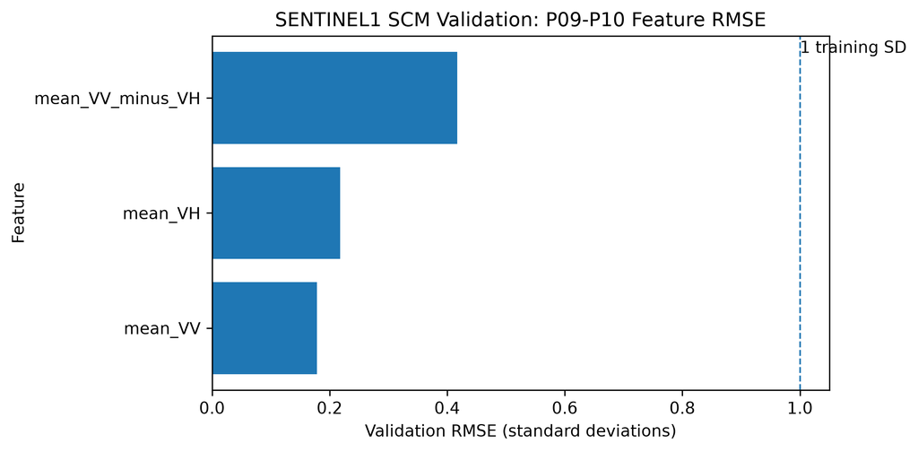

Sentinel-1 SCM validation RMSE by feature. All three features fall well below the 1 SD reference line, indicating that the SCM donor weights generalize strongly to the held-out periods.

VV and VH are the most reliably reconstructed features (mean RMSE 0.18 and 0.22 SD respectively). VV−VH is harder to match but still well below 1 SD (mean 0.42), reflecting the additional complexity of the polarimetric ratio.

#### Sentinel-1 — RMSE heatmap by treatment site and feature

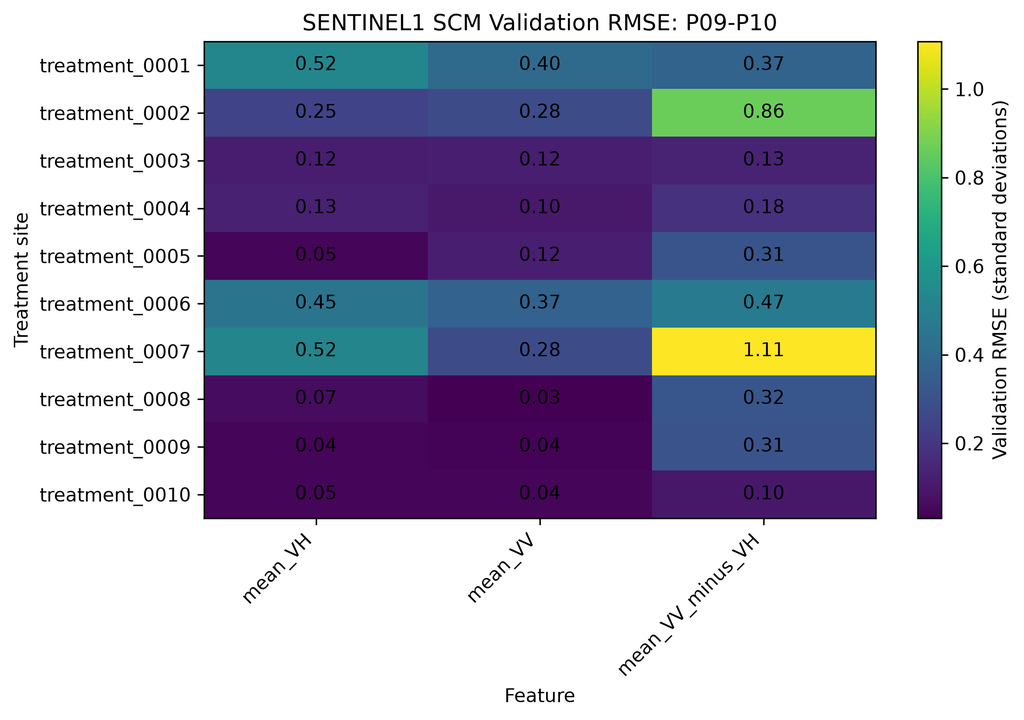

Each cell shows the SCM validation RMSE (in training SDs) for one treatment site × feature combination. Most cells are dark (low error). The only outlier is treatment_0007 × VV_minus_VH (1.11 SD), where a single donor dominates the weights.

#### Sentinel-2 — feature-level validation RMSE (average across 10 sites)

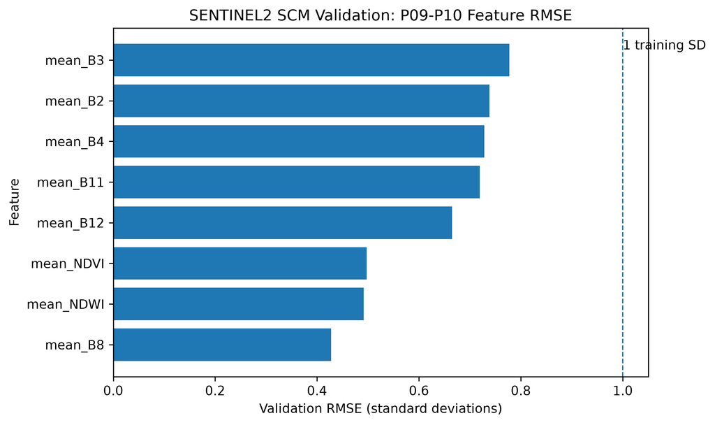

Sentinel-2 SCM validation RMSE by feature. All features remain below 1 SD but are substantially higher than Sentinel-1. Vegetation indices (NDVI, NDWI) and NIR (B8) perform best; visible and SWIR bands (B2–B4, B11–B12) are noticeably harder to match.

B8 (NIR) achieves the lowest mean RMSE (0.43 SD), followed by NDWI and NDVI (~0.49–0.50 SD). The visible bands (B2–B4) and SWIR bands (B11–B12) range from 0.67 to 0.78 SD. These are still below the 1 SD threshold on average, but the higher variance across sites means individual site–feature combinations can be problematic.

#### Sentinel-2 — RMSE heatmap by treatment site and feature

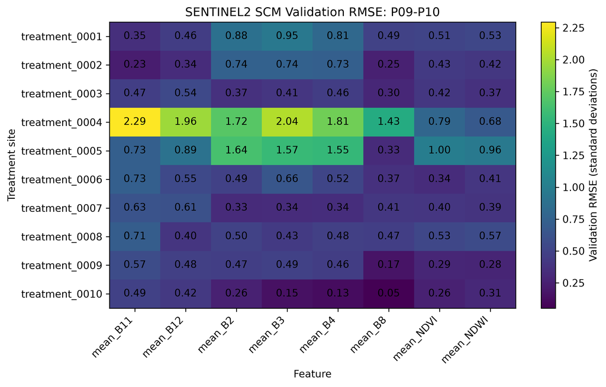

Each cell shows the Sentinel-2 SCM validation RMSE. Treatment_0004 (top-highlighted row) is the dominant outlier, with RMSE exceeding 1.4–2.3 SD across most features. All other sites remain at moderate levels. B8, NDVI, and NDWI are the most consistently well-fitted features.

### What the results mean

**Sentinel-1** counterfactuals can be considered validated at 9 of 10 treatment sites. The donor weights estimated from P01–P08 predict the biweekly VV and VH trajectories in the held-out periods with errors well under half a training standard deviation, providing strong evidence that the SCM weights capture a stable treatment-control relationship.

**Sentinel-2** validation is more mixed. The vegetation and water indices (NDVI, NDWI, B8) generalize reasonably at most sites. The visible and SWIR bands are harder to match, likely because biweekly optical composites retain more residual cloud-masking variability than radar data. Treatment_0004 should be treated with caution in any Sentinel-2–based analysis: either a larger donor pool, better cloud-screened periods, or a Sentinel-1-only specification would be more defensible for this site.

The post-hurricane effect estimates in `05_post_hurricane_effects.csv` use the same frozen weights. For sites and features that passed validation, those estimates can be interpreted as genuine departures from the expected no-hurricane trajectory. For **poor** sites the effect estimates are unreliable.

### Output files

```
test/scm_validation/
├── 01_extracted_features.csv          ← mean band values per site × period × sensor
├── 02_scm_weights.csv                 ← donor weights per treatment × sensor
├── 03_training_fit.csv                ← actual vs synthetic (P01–P08, standardized)
├── 04_validation_results.csv          ← actual vs synthetic (P09–P10, standardized)
├── 05_post_hurricane_effects.csv      ← actual vs synthetic (P11–P20, original units)
├── 06_scm_site_summary.csv            ← per-site RMSE, ratio, and validation flag
├── 07_scm_validation.xlsx             ← all above sheets in one workbook
├── 08_feature_validation_rmse.csv     ← RMSE per treatment × feature (P09–P10)
├── 09_feature_validation_rmse_summary.csv  ← RMSE averaged across sites per feature
└── figures/
    ├── sentinel1_feature_validation_rmse.png
    ├── sentinel2_feature_validation_rmse.png
    ├── sentinel1_treatment_feature_rmse_heatmap.png
    └── sentinel2_treatment_feature_rmse_heatmap.png
```

**ASCM Validation**

### What was done

Notebook 15 implements **Ridge Augmented Synthetic Control (Ridge ASCM)** following Ben-Michael, Feller, and Rothstein (2021). It uses the same biweekly imagery, the same 10-treatment / 5-donor-per-treatment sample, and the same temporal design as the SCM notebook, and directly compares Ridge ASCM against plain SCM on the held-out P09–P10 validation periods.

The key question is: does the ridge augmentation correction improve out-of-sample counterfactual prediction, or does it introduce extrapolation that makes things worse?

> **Reference:** Ben-Michael, E., Feller, A., & Rothstein, J. (2021). *The Augmented Synthetic Control Method.* Journal of the American Statistical Association, 116(536), 1789–1803.

### How Ridge ASCM extends SCM

Plain SCM requires non-negative weights that sum to one. When the donor pool is small or the treatment site lies outside the convex hull of the donors, SCM cannot achieve a close pre-treatment fit. Ridge ASCM addresses this by adding a **bias-correction term** that allows weights to go negative and extrapolate beyond the convex hull.

Starting from the SCM solution $\hat{\mathbf{w}}^\text{SCM}$, Ridge ASCM solves:

$$\min_{\mathbf{w}} \;
\frac{1}{2\lambda} \|\mathbf{X}_T - \mathbf{X}_C \mathbf{w}\|^2
\;+\;
\frac{1}{2} \|\mathbf{w} - \hat{\mathbf{w}}^\text{SCM}\|^2
\quad \text{subject to} \quad \sum_j w_j = 1$$

The ridge penalty $\lambda$ controls how far the ASCM weights deviate from the SCM solution:

| $\lambda$ value | Behavior |
| --- | --- |
| Very large (e.g. 10 000) | ASCM ≈ SCM; essentially no correction |
| Moderate | Meaningful bias correction with limited extrapolation |
| Very small | Aggressive correction; high risk of extrapolation |

Unlike SCM, ASCM allows **negative weights**, meaning it can extrapolate beyond the convex hull of the donor pool to achieve a better pre-treatment fit.

### Lambda selection

$\lambda$ is selected separately for each treatment site × sensor combination using **leave-one-training-period-out cross-validation** on P01–P08 only. P09–P10 are never used in lambda selection.

Selected $\lambda$ values from the current run:

| Treatment | Sentinel-1 $\lambda$ | Sentinel-2 $\lambda$ |
| --- | --- | --- |
| treatment_0001 | 2.0 | 10 000 |
| treatment_0002 | 6.3 | 7.9 |
| treatment_0003 | 20.0 | 10 000 |
| treatment_0004 | 20.0 | 2.0 |
| treatment_0005 | 10 000 | 0.8 |
| treatment_0006 | 31.6 | 10 000 |
| treatment_0007 | 10 000 | 10 000 |
| treatment_0008 | 1.6 | 0.25 |
| treatment_0009 | 10 000 | 10 000 |
| treatment_0010 | 10 000 | 2.5 |

When $\lambda$ = 10 000 the CV selected essentially no correction, meaning the SCM already achieves the best possible fit given this donor pool and ASCM offers no further benefit.

### Results

#### Sentinel-1 — SCM vs Ridge ASCM validation RMSE

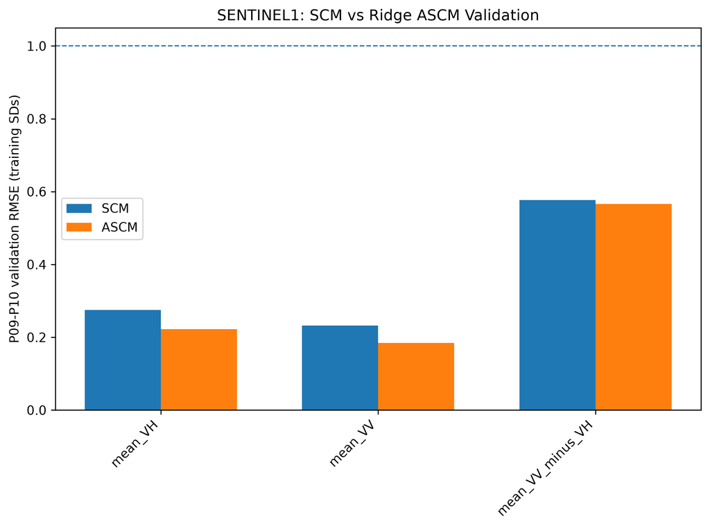

Sentinel-1 comparison of mean P09–P10 validation RMSE across all 10 sites. ASCM (orange) is lower than SCM (blue) for all three Sentinel-1 features. The improvement is most pronounced for VV and VH (roughly 0.05–0.06 SD reduction). The dashed line marks the 1 SD reference.

For Sentinel-1, Ridge ASCM consistently reduces the average validation RMSE. VV improves from 0.232 to 0.185 SD (−20%), VH from 0.275 to 0.222 SD (−19%), and VV_minus_VH from 0.577 to 0.566 SD (−2%). The gains are modest but consistent — ASCM improved at least one feature for 5 of 10 sites for VV and VH.

#### Sentinel-1 — ASCM heatmap by treatment site and feature

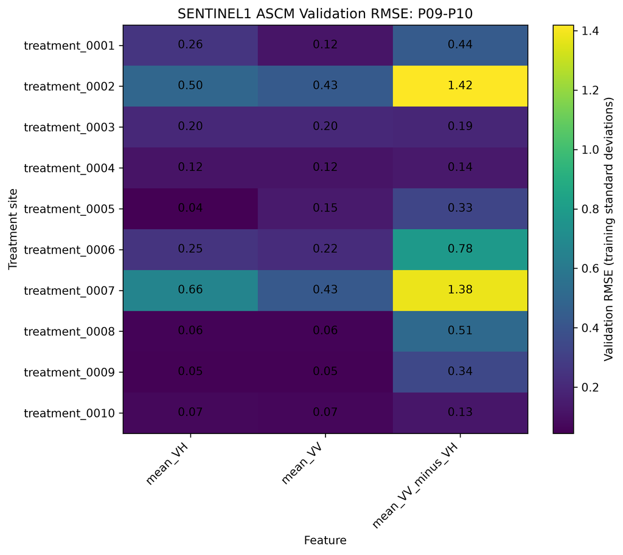

ASCM reduced RMSE for treatment_0001 VH (0.69 → 0.26 SD) and treatment_0002 VV_minus_VH (1.59 → 1.42 SD). Treatment_0007 is the clear failure case: the $\lambda$ = 10 000 selection means the CV found no benefit from correction, yet negative weights still increased the VV_minus_VH error from 1.11 to 1.38 SD. This illustrates that when SCM already concentrates all weight on a single donor, the ridge augmentation cannot help.

#### Sentinel-2 — SCM vs Ridge ASCM validation RMSE

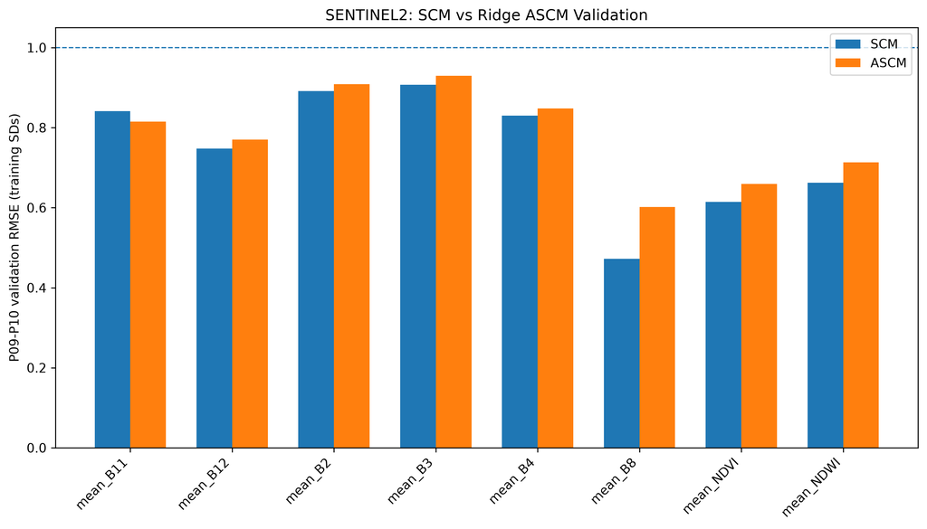

Sentinel-2 comparison. For most features, ASCM (orange) is equal to or slightly higher than SCM (blue) — Ridge ASCM does not improve Sentinel-2 counterfactual prediction on average. B8 shows the largest degradation (0.47 → 0.60 SD). B11 is the only feature where ASCM marginally helps on average.

Unlike Sentinel-1, Ridge ASCM **does not consistently improve** Sentinel-2 counterfactual prediction. The mean validation RMSE is higher under ASCM for 7 of the 8 Sentinel-2 features. B8 (NIR) shows the worst degradation: 0.472 → 0.601 SD. B11 (SWIR-1) is the only feature that benefits slightly on average (0.841 → 0.815 SD).

#### Trajectory example — treatment_0001 NDVI

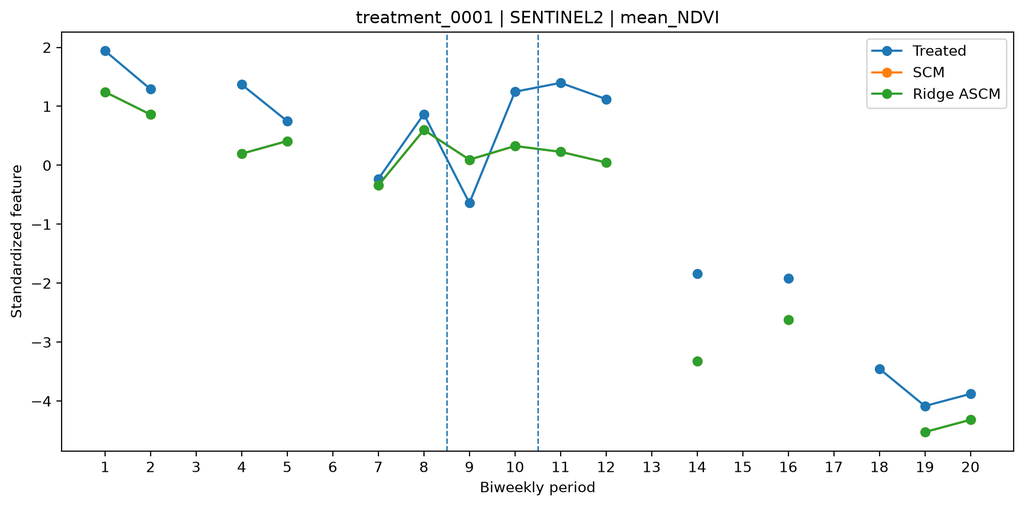

Observed (blue), SCM counterfactual (orange), and Ridge ASCM counterfactual (green) for treatment_0001 mean NDVI. The two dashed vertical lines mark the training/validation and validation/post-treatment boundaries (P08|P09 and P10|P11). Training: P1–P8. Validation: P9–P10. Post-hurricane effect: P11–P20.

### What the results mean

**Sentinel-1 with Ridge ASCM:** The augmentation provides a small but consistent improvement in radar-based counterfactual prediction. For sites where SCM already generalizes well (most sites), the improvement is marginal. For a few sites where SCM has imperfect pre-training fit (treatment_0001, _0002, _0006), ASCM meaningfully reduces the held-out error. The exception is treatment_0007, where all SCM weight is concentrated on a single donor; ASCM’s extrapolation then overshoots, increasing error. In practice, Sentinel-1 ASCM is a modest but safe upgrade over plain SCM for most sites.

**Sentinel-2 with Ridge ASCM:** The augmentation is **unreliable** with the current small donor pool (5 sites). When $\lambda$ is small (e.g. treatment_0005 Sentinel-2 at λ = 0.8 or treatment_0008 at λ = 0.25), ASCM allows large negative weights that extrapolate aggressively beyond the donor convex hull. Treatment_0005 Sentinel-2 is the most severe failure — some features degrade by more than 1 SD relative to SCM. This is not a flaw in the ASCM methodology itself, but rather a sign that **five donors are too few** to safely permit extrapolation for noisy optical data.

**Overall conclusion:** For the current 5-donor working sample, plain SCM is the safer default for Sentinel-2. Ridge ASCM is preferable for Sentinel-1 at sites where the SCM validation flag is “good” and the selected λ is not at the maximum. Expanding the donor pool to 10–20 sites would likely improve ASCM’s stability for Sentinel-2 as well.

**Post-hurricane effects:** The trajectory plots reveal large, sustained treatment-counterfactual divergences for several sites after P10, particularly in NDVI and NDWI. These divergences are consistent with hurricane-induced vegetation damage and surface disturbance that persists well beyond the immediate event window. Formal effect estimates are in `08_post_hurricane_effects.csv` (ASCM) and should be interpreted together with the site-level validation flags.

### Output files

```
test/ascm_validation/
├── 01_extracted_feature_panel.csv     ← mean band values per site × period × sensor
├── 02_scm_weights.csv                 ← SCM donor weights (used as ASCM starting point)
├── 03_ascm_weights.csv                ← final Ridge ASCM weights (may be negative)
├── 04_lambda_selection.csv            ← CV RMSE across lambda grid per site × sensor
├── 05_validation_predictions.csv      ← SCM and ASCM predictions on P09–P10
├── 06_validation_summary.csv          ← per-site SCM vs ASCM RMSE comparison
├── 07_feature_validation_rmse.csv     ← per-site × feature RMSE for both methods
├── 08_post_hurricane_effects.csv      ← actual vs ASCM counterfactual (P11–P20)
├── 09_weight_diagnostics.csv          ← negative weight counts and extrapolation distance
├── 10_scm_vs_ascm_summary.csv         ← feature-level SCM vs ASCM average comparison
├── ascm_results.xlsx                  ← all sheets in one workbook
└── figures/
    ├── sentinel1_scm_vs_ascm_validation.png
    ├── sentinel2_scm_vs_ascm_validation.png
    ├── sentinel1_scm_validation_rmse_heatmap.png
    ├── sentinel1_ascm_validation_rmse_heatmap.png
    ├── sentinel2_scm_validation_rmse_heatmap.png
    ├── sentinel2_ascm_validation_rmse_heatmap.png
    └── treatment_NNNN_{sensor}_{feature}_trajectory.png  ← 110 trajectory plots
```

### Software

The workflow was built in Python using **Google Earth Engine**, **geemap**, **GeoPandas**, **Rasterio**, **NumPy**, **pandas**, **Matplotlib**, and **Shapely**.